# first_ponderada

Luiz Covas

2025-02-09

## Preparando o Ambiente

Nosso grupo decidiu separar um dataframe para cada indivíduo, permitindo uma análise individualizada e um entendimento mais detalhado de cada conjunto de dados.

Para realizar a análise exploratória, utilizaremos as bibliotecas listadas abaixo, essenciais para a criação de gráficos e a manipulação dos dados. Portanto, é necessário instalá-las previamente.

```r
# Carregue pacotes essenciais
library(ggplot2)     # Para gráficos
library(dplyr)       # Para manipulação de dados
library(corrplot)    # Para visualizar a matriz de correlação
library(scales)

# Se optar por PCA com FactoMineR, carregue também:
library(FactoMineR)
library(factoextra)  # Para visualizações de PCA
```

# Importação e Visualização dos Dados

O formato do seu conjunto de dados (CSV, Excel, etc.) determinará a função mais adequada para a importação. Abaixo você pode ver a utilização da função para leitura de CSV que é o nosso caso.

dados <- read.csv(“seu_arquivo.csv”, header = TRUE, sep = “,”)

```r
dados <- read.csv("C:/Users/luiz_/Documentos/modulo11/InteliResultados.csv", header = TRUE, sep = ",")
```

# Iniciando a Exploração dos Dados

Após carregar os dados, iniciaremos a visualização das primeiras linhas para compreender sua estrutura, identificar possíveis padrões e verificar a qualidade das informações.

```r
head(dados)
```

```
##             ID RESULT_ID RESULT_DESCRIPTION               CAPTURE_TIME STATUS
## 1 2024-3821101    53P007    ABASTEC. CÂMBIO 2019-02-14-08.20.57.000000    NOK
## 2 2024-3851264    53P007    ABASTEC. CÂMBIO 2019-02-14-08.31.27.000000    NOK
## 3 2024-3851264    53P007    ABASTEC. CÂMBIO 2019-02-14-08.31.57.000000    NOK
## 4 2024-3851264    53P007    ABASTEC. CÂMBIO 2019-02-14-08.33.57.000000    NOK
## 5 2024-3851264    53P007    ABASTEC. CÂMBIO 2019-02-14-08.34.27.000000    NOK
## 6 2024-3851264    53P007    ABASTEC. CÂMBIO 2019-02-14-08.34.57.000000    NOK
```

# Compreendendo a Estrutura dos Dados

A função str() permite visualizar a estrutura do dataframe, incluindo os tipos de dados de cada coluna e uma visão geral do conteúdo. Essa análise é feita para identificar possíveis inconsistências e garantir que os dados estejam no formato adequado para a exploração.

```r
str(dados)
```

```
## 'data.frame':    1932313 obs. of  5 variables:
##  $ ID                : chr  "2024-3821101" "2024-3851264" "2024-3851264" "2024-3851264" ...
##  $ RESULT_ID         : chr  "53P007" "53P007" "53P007" "53P007" ...
##  $ RESULT_DESCRIPTION: chr  "ABASTEC. CÂMBIO" "ABASTEC. CÂMBIO" "ABASTEC. CÂMBIO" "ABASTEC. CÂMBIO" ...
##  $ CAPTURE_TIME      : chr  "2019-02-14-08.20.57.000000" "2019-02-14-08.31.27.000000" "2019-02-14-08.31.57.000000" "2019-02-14-08.33.57.000000" ...
##  $ STATUS            : chr  "NOK" "NOK" "NOK" "NOK" ...
```

# Criando Novas Colunas para a Análise

Como nosso conjunto de dados é relativamente pequeno, precisaremos criar novas colunas a partir das existentes para enriquecer nossa análise inicial.

O primeiro passo será converter a coluna ID em um formato numérico. Isso nos permitirá, posteriormente, investigar possíveis correlações entre essa variável e as demais.

```r
dados$ID <- as.numeric(gsub("-", "", dados$ID))
```

# Refinando a Coluna de Data

Em seguida, iremos transformar a coluna data de formato character (chr) para datetime. Além disso, para uma análise mais detalhada, vamos decompor essa informação em colunas mais granulares, como ano, mês, dia e hora. Isso permitirá uma exploração mais precisa e a identificação de padrões temporais nos dados.

### Transformando a coluna em Datetime

```r
dados$CAPTURE_TIME <- strptime(dados$CAPTURE_TIME, format="%Y-%m-%d-%H.%M.%OS")
```

### Criando colunas a partir de DateTime

```r
dados$ano <- format(dados$CAPTURE_TIME, "%Y")
dados$mes <- format(dados$CAPTURE_TIME, "%m")
dados$dia <- format(dados$CAPTURE_TIME, "%d")
dados$hora <- format(dados$CAPTURE_TIME, "%H")
dados$minuto <- format(dados$CAPTURE_TIME, "%M")
```

### Convertendo as colunas para inteiro

```r
dados$ano <- as.integer(dados$ano)
dados$mes <- as.integer(dados$mes)
dados$dia <- as.integer(dados$dia)
dados$hora <- as.integer(dados$hora)
dados$minuto <- as.integer(dados$minuto)
```

### Adicionando a Coluna de Turno

Também incluiremos uma nova coluna que classifica os registros por turno, conforme solicitado pelo parceiro. Essa categorização ajudará a gerar insights mais estratégicos, permitindo uma análise diferenciada dos dados ao longo do dia.

```r
dados$turno <- case_when(
  dados$hora >= 23 ~ 3,
  dados$hora >= 0 & dados$hora <  6 ~ 3,
  dados$hora >= 6 & dados$hora < 15 ~ 1,
  dados$hora >= 15 & dados$hora < 23 ~ 2,
)
```

```r
head(dados)
```

```
##            ID RESULT_ID RESULT_DESCRIPTION        CAPTURE_TIME STATUS  ano mes dia hora minuto turno
## 1 20243821101    53P007    ABASTEC. CÂMBIO 2019-02-14 08:20:57    NOK 2019   2  14    8     20     1
## 2 20243851264    53P007    ABASTEC. CÂMBIO 2019-02-14 08:31:27    NOK 2019   2  14    8     31     1
## 3 20243851264    53P007    ABASTEC. CÂMBIO 2019-02-14 08:31:57    NOK 2019   2  14    8     31     1
## 4 20243851264    53P007    ABASTEC. CÂMBIO 2019-02-14 08:33:57    NOK 2019   2  14    8     33     1
## 5 20243851264    53P007    ABASTEC. CÂMBIO 2019-02-14 08:34:27    NOK 2019   2  14    8     34     1
## 6 20243851264    53P007    ABASTEC. CÂMBIO 2019-02-14 08:34:57    NOK 2019   2  14    8     34     1
```

```r
summary(dados)
```

```
##        ID             RESULT_ID         RESULT_DESCRIPTION  CAPTURE_TIME
##  Min.   :2.024e+10   Length:1932313     Length:1932313     Min.   :2019-02-14 08:20:57.00
##  1st Qu.:2.024e+10   Class :character   Class :character   1st Qu.:2024-10-31 22:35:28.00
##  Median :2.024e+10   Mode  :character   Mode  :character   Median :2024-11-25 08:13:39.00
##  Mean   :2.025e+10                                         Mean   :2024-11-15 17:58:15.85
##  3rd Qu.:2.025e+10                                         3rd Qu.:2024-12-17 06:18:26.00
##  Max.   :2.025e+10                                         Max.   :2025-01-28 11:20:36.00
##     STATUS               ano            mes              dia             hora           minuto
##  Length:1932313     Min.   :2019   Min.   : 1.000   Min.   : 1.00   Min.   : 0.00   Min.   : 0.00
##  Class :character   1st Qu.:2024   1st Qu.: 6.000   1st Qu.:11.00   1st Qu.: 9.00   1st Qu.:15.00
##  Mode  :character   Median :2024   Median :11.000   Median :17.00   Median :14.00   Median :29.00
##                     Mean   :2024   Mean   : 8.677   Mean   :16.79   Mean   :13.84   Mean   :29.62
##                     3rd Qu.:2024   3rd Qu.:11.000   3rd Qu.:23.00   3rd Qu.:18.00   3rd Qu.:45.00
##                     Max.   :2025   Max.   :12.000   Max.   :31.00   Max.   :23.00   Max.   :59.00
##      turno
##  Min.   :1.000
##  1st Qu.:1.000
##  Median :1.000
##  Mean   :1.509
##  3rd Qu.:2.000
##  Max.   :3.000
```

## Descrição das Variáveis

[output not shown]

Para entender melhor os padrões temporais das capturas, vamos analisar a distribuição dos registros ao longo do dia. O histograma abaixo exibe a frequência de capturas por hora, permitindo identificar possíveis picos de atividade e momentos de menor ocorrência.

Esse tipo de visualização é útil para detectar padrões sazonais e ajudar na tomada de decisões baseadas no comportamento dos dados ao longo do tempo.

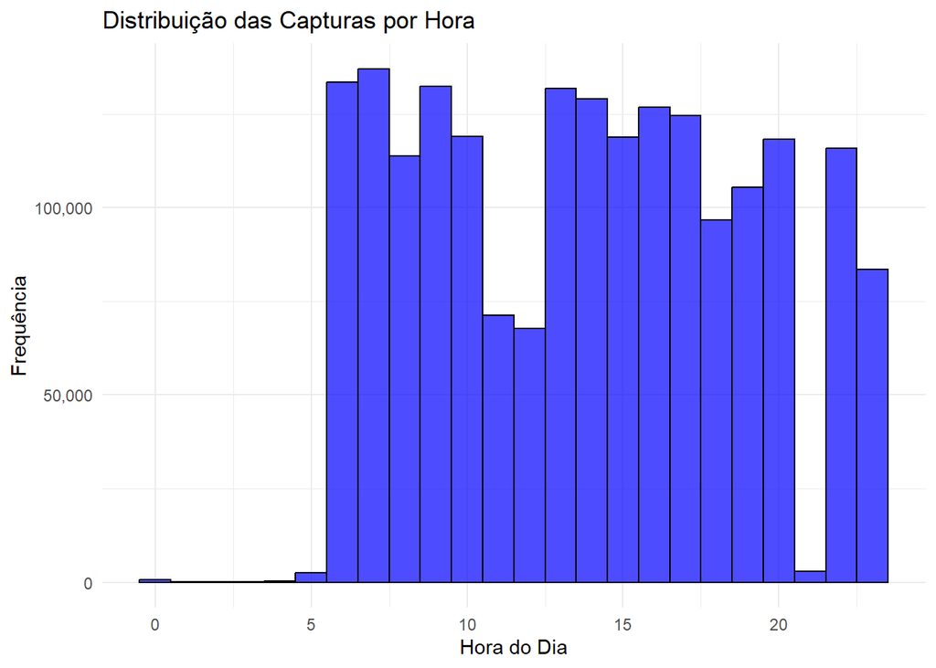

```r
# Histogramas para as variáveis temporais (hora e minuto)
ggplot(dados, aes(x=hora)) +
  geom_histogram(binwidth=1, fill="blue", color="black", alpha=0.7) +
  labs(title="Distribuição das Capturas por Hora", x="Hora do Dia", y="Frequência") +
  scale_y_continuous(labels = scales::comma) +  # Chama a função corretamente
  theme_minimal()
```

Além do histograma, utilizamos um gráfico de densidade para visualizar a distribuição suave das capturas ao longo do dia. Diferente do histograma, esse gráfico permite identificar padrões de concentração sem depender do tamanho das classes, fornecendo uma visão mais fluida da frequência das capturas em cada horário.

Com essa abordagem, conseguimos detectar os períodos de maior e menor intensidade de capturas, auxiliando na identificação de tendências e padrões sazonais nos dados.

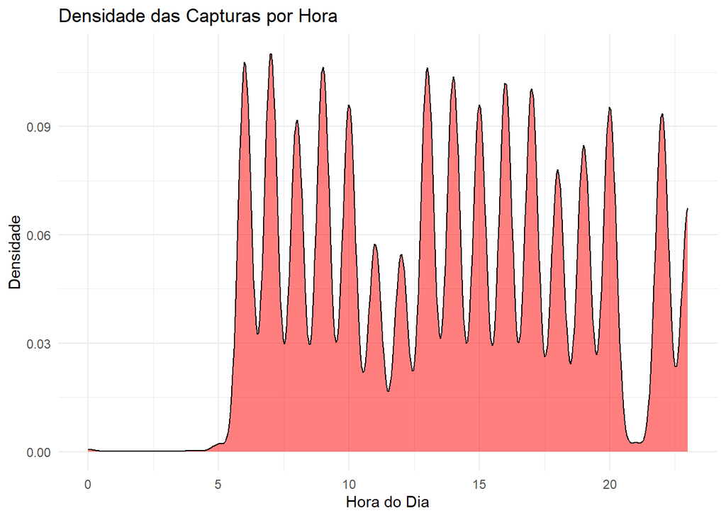

```r
# Gráfico de densidade para a variável hora
ggplot(dados, aes(x=hora)) +
  geom_density(fill="red", alpha=0.5) +
  labs(title="Densidade das Capturas por Hora", x="Hora do Dia", y="Densidade") +
  theme_minimal()
```

O boxplot abaixo tem o objetivo de comparar a distribuição das capturas ao longo do dia para cada categoria da variável STATUS. Essa visualização permite identificar variações nos horários em que os diferentes status ocorrem com maior frequência.

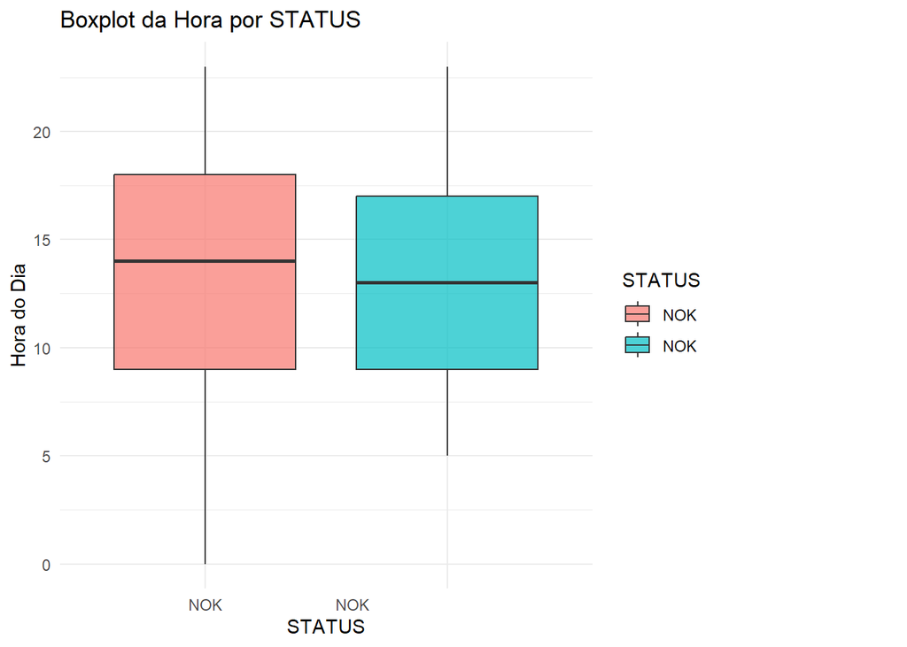

```r
# Boxplot para visualizar a distribuição da variável hora por STATUS
ggplot(dados, aes(x=STATUS, y=hora, fill=STATUS)) +
  geom_boxplot(alpha=0.7) +
  labs(title="Boxplot da Hora por STATUS", x="STATUS", y="Hora do Dia") +
  theme_minimal()
```

Nesta etapa, utilizamos o método do Intervalo Interquartil (IQR) para detectar possíveis outliers nas variáveis numéricas.

```r
### Função para detectar outliers pelo método do IQR
detect_outliers <- function(df, coluna) {
  Q1 <- quantile(df[[coluna]], 0.25, na.rm = TRUE)  # Primeiro quartil
  Q3 <- quantile(df[[coluna]], 0.75, na.rm = TRUE)  # Terceiro quartil
  IQR_value <- Q3 - Q1  # Intervalo Interquartil

  # Definir limites superior e inferior para outliers
  lower_bound <- Q1 - 1.5 * IQR_value
  upper_bound <- Q3 + 1.5 * IQR_value

  # Filtrar os outliers
  outliers <- df %>%
    filter(df[[coluna]] < lower_bound | df[[coluna]] > upper_bound)

  return(outliers)
}
```

```r
# Criando variáveis a serem analisadas para outliers
variaveis_numericas <- c("mes", "dia", "hora")
```

# Análise Visual com Boxplots

Criamos boxplots para as variáveis mes, dia e hora, permitindo visualizar a dispersão dos dados e destacar potenciais outliers. Caso existisse, estariam representado por pontos azuis indicando possíveis valores atípicos.

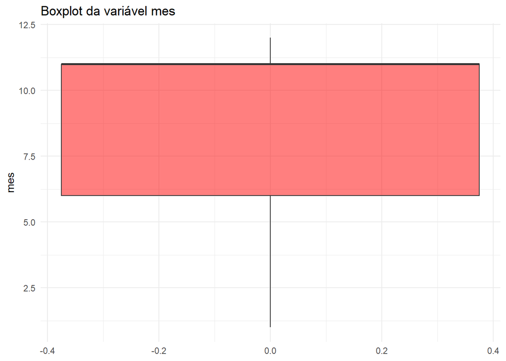

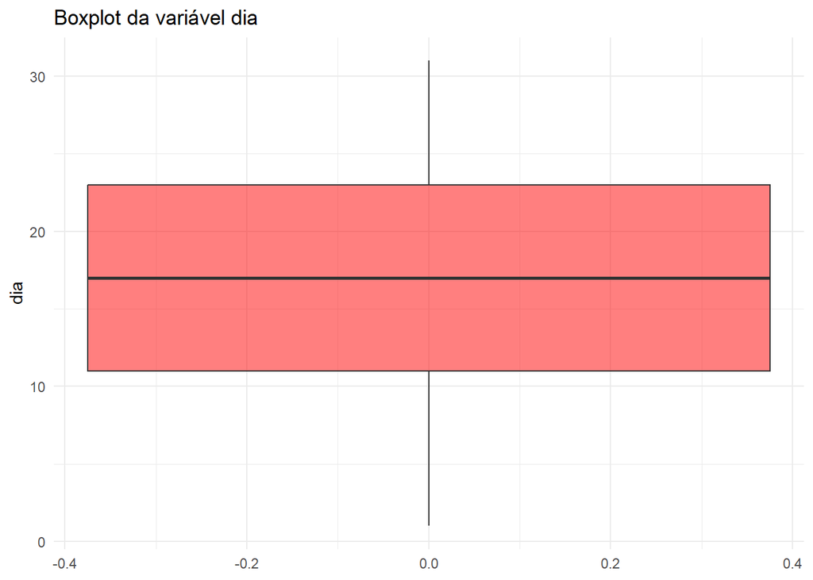

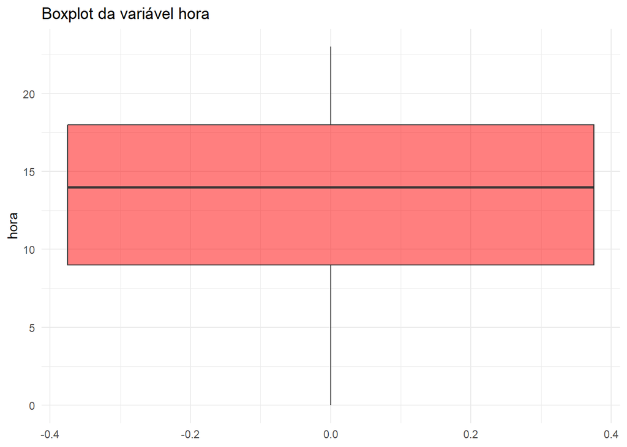

```r
# Criando boxplots para visualizar os outliers
for (var in variaveis_numericas) {
  print(
    ggplot(dados, aes(y = .data[[var]])) +
      geom_boxplot(fill="red", alpha=0.5, outlier.color="blue", outlier.shape=16) +
      labs(title = paste("Boxplot da variável", var), y = var) +
      theme_minimal()
  )
}
```

Aqui, podemos verificar alguns padrões de ocorrências concentrados em alguns meses e uma janela de tempo dentro dos meses.

O gráfico de barras abaixo apresenta a frequência de eventos em cada turno do dia. Essa visualização nos ajuda a identificar padrões e variações na quantidade de registros ao longo dos diferentes períodos.

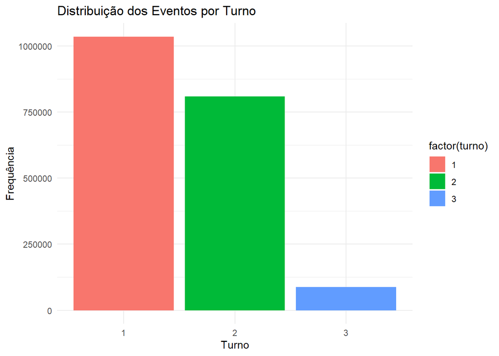

```r
ggplot(dados, aes(x=factor(turno), fill=factor(turno))) +
  geom_bar() +
  labs(title="Distribuição dos Eventos por Turno", x="Turno", y="Frequência") +
  theme_minimal()
```

Nesta seção, realizamos uma análise dos eventos mais frequentes com base na variável RESULT_DESCRIPTION. O objetivo é identificar os 10 tipos de resultados mais comuns e exibi-los de forma clara em um gráfico de barras.

### Definição do Número de Categorias

```r
top_n_resultados <- 10
```

### Contagem de Ocorrências

```r
top_resultados <- dados %>%
  count(RESULT_DESCRIPTION, name="freq") %>%
  arrange(desc(freq)) %>%
  head(top_n_resultados)
```

### Filtragem dos Dados

```r
dados_filtrados <- dados %>%
  filter(RESULT_DESCRIPTION %in% top_resultados$RESULT_DESCRIPTION)
```

Essa visualização permite compreender rapidamente quais tipos de resultados ocorrem com maior frequência, auxiliando no entendimento dos dados.

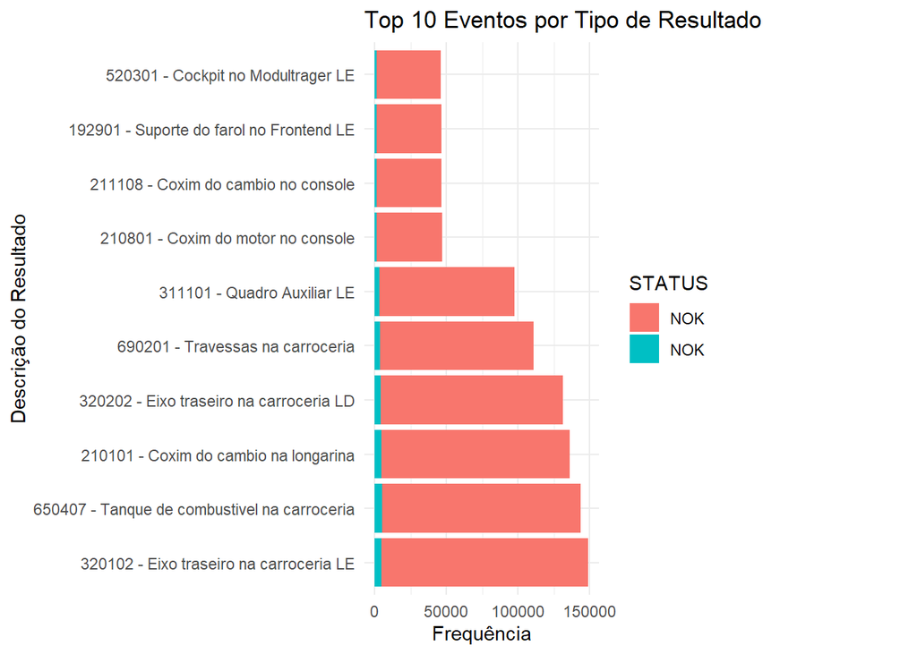

```r
# Criar o gráfico de barras com apenas os resultados mais frequentes
ggplot(dados_filtrados, aes(x=reorder(RESULT_DESCRIPTION, -table(RESULT_DESCRIPTION)[RESULT_DESCRIPTION]), fill=STATUS)) +
  geom_bar() +
  coord_flip() +  # Rotaciona para melhor leitura
  labs(title=paste("Top", top_n_resultados, "Eventos por Tipo de Resultado"),
       x="Descrição do Resultado", y="Frequência") +
  theme_minimal()
```

### Transformando a coluna ID em um dado númerico para analise de correlação

```r
dados$ID <- as.numeric(dados$ID)
```

Nesta etapa, realizamos uma análise de correlação entre as variáveis numéricas do conjunto de dados. A correlação é uma medida estatística que indica o grau de associação entre duas variáveis, variando entre -1 (correlação negativa perfeita), 0 (nenhuma correlação) e 1 (correlação positiva perfeita). Essa análise é útil para identificar relações entre diferentes variáveis e pode auxiliar na modelagem preditiva e tomada de decisões.

## Seleção das Variáveis Numéricas

```r
# Selecionar apenas as colunas numéricas para a correlação
dados_numericos <- dados %>%
  select(where(is.numeric))
```

## Cálculo da Matriz de Correlação

```r
matriz_cor <- cor(dados_numericos, use="pairwise.complete.obs")
```

## Exibição da Matriz no Console

```r
print(matriz_cor)
```

```
##                  ID          ano          mes          dia         hora       minuto        turno
## ID      1.000000000  0.908859613 -0.707658816  0.180496983  0.025604451  0.004393264  0.015023464
## ano     0.908859613  1.000000000 -0.907939365  0.191872444  0.001643821  0.003223390 -0.004825143
## mes    -0.707658816 -0.907939365  1.000000000 -0.255117482  0.021397262 -0.000804963  0.019013474
## dia     0.180496983  0.191872444 -0.255117482  1.000000000 -0.025972354 -0.001196553 -0.020723889
## hora    0.025604451  0.001643821  0.021397262 -0.025972354  1.000000000 -0.023490658  0.849042611
## minuto  0.004393264  0.003223390 -0.000804963 -0.001196553 -0.023490658  1.000000000 -0.035600500
## turno   0.015023464 -0.004825143  0.019013474 -0.020723889  0.849042611 -0.035600500  1.000000000
```

## Visualização Gráfica da Correlação

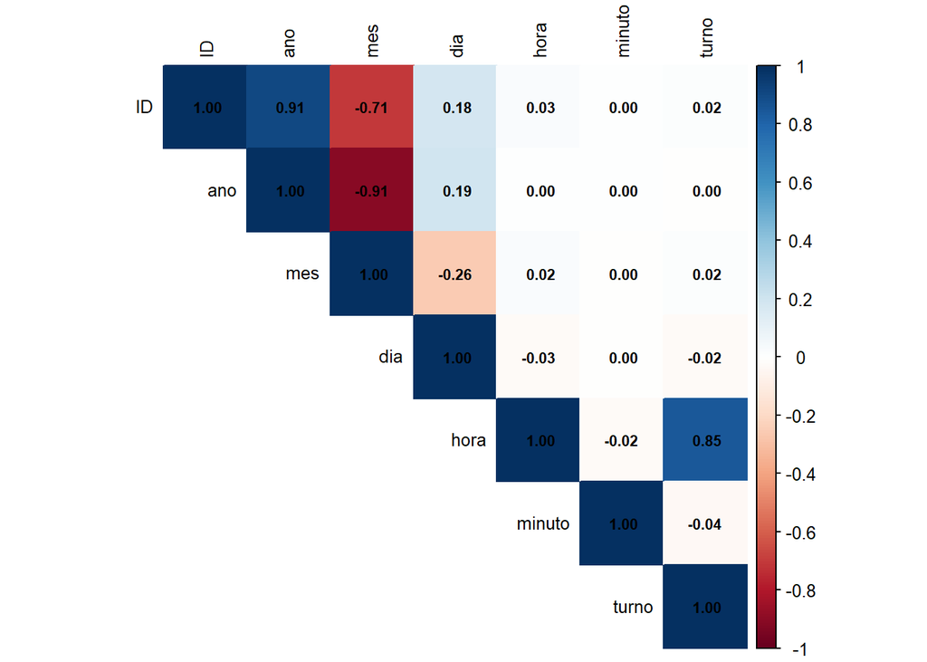

```r
# Visualizar a matriz de correlação com corrplot
corrplot(matriz_cor, method="color", type="upper",
         tl.col="black", tl.cex=0.8,
         addCoef.col="black", number.cex=0.7)
```

A Análise de Componentes Principais (PCA - Principal Component Analysis) é uma técnica estatística utilizada para redução de dimensionalidade em conjuntos de dados com muitas variáveis correlacionadas. Nesse caso, como temos poucos dados correlacionados, não faz muito sentido uma aplicação de analise PCA. Mas adicionei uma forma de realizar essa visualização abaixo:

```r
# Executando o PCA (escalando os dados para padronização)
pca_result <- prcomp(dados_numericos, center = TRUE, scale. = TRUE)
```

```r
# Visualizar a importância de cada componente principal
summary(pca_result)
```

```
## Importance of components:
##                           PC1    PC2    PC3    PC4     PC5     PC6     PC7
## Standard deviation     1.6615 1.3613 0.9991 0.9642 0.53614 0.38803 0.14163
## Proportion of Variance 0.3944 0.2647 0.1426 0.1328 0.04106 0.02151 0.00287
## Cumulative Proportion  0.3944 0.6591 0.8017 0.9346 0.97563 0.99713 1.00000
```

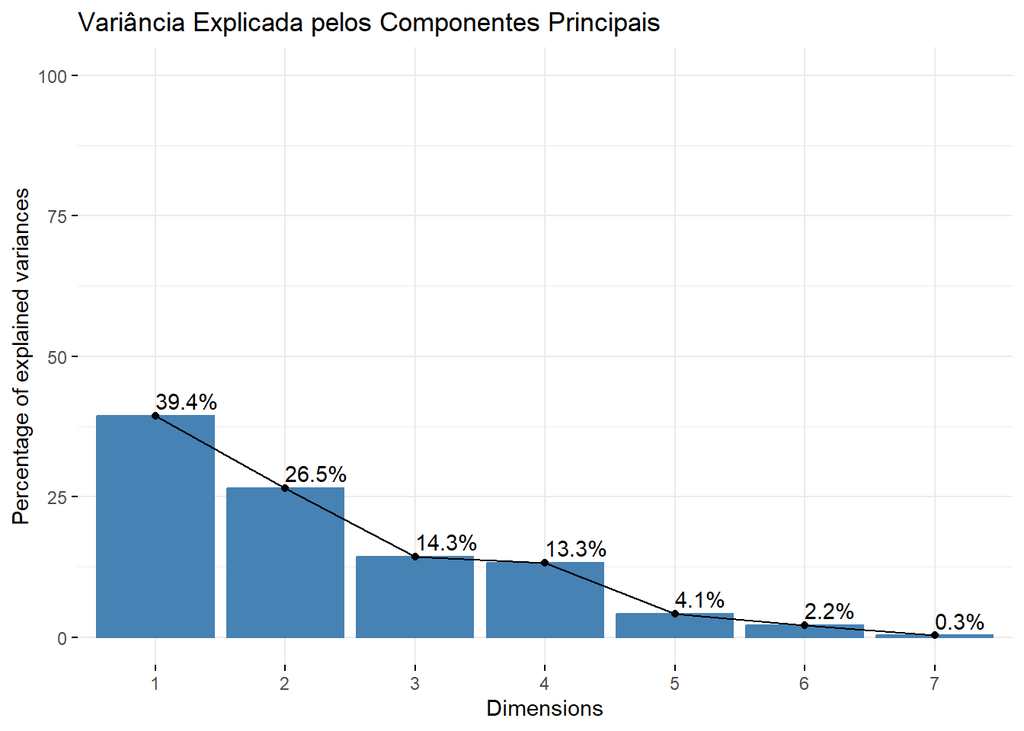

```r
fviz_eig(pca_result, addlabels = TRUE, ylim = c(0, 100)) +
  labs(title="Variância Explicada pelos Componentes Principais")
```

Obs: Código para gerar a visualização não roda

```r
##fviz_pca_var(pca_result, col.var = "contrib", gradient.cols = c("blue", "red"), repel = TRUE) +
##  labs(title="Contribuição das Variáveis nos Componentes")
```

Obs: Código para gerar a visualização não roda

```r
##fviz_pca_ind(pca_result, col.ind = "cos2", gradient.cols = c("blue", "red"), repel = TRUE) +
##  labs(title="Mapa dos Registros no Espaço PCA")
```

Para refinar a análise, a coluna de data foi dividida em componentes individuais (ano, mês, dia e hora) e também foi criada a variável turno, com o intuito de identificar padrões temporais. Embora essa abordagem não tenha gerado insights profundos, foi possível observar que alguns horários específicos (11h, 12h e 21h) apresentam uma aparente redução na quantidade de problemas. Além disso, identificamos que o primeiro turno registra um pico maior de ocorrências de falhas, o que pode ser um indicativo de sobrecarga ou outros fatores operacionais.

Apesar dessas observações, a análise de correlação entre as variáveis não revelou relações estatisticamente significativas que pudessem ajudar a entender melhor os dados, com exceção das próprias variáveis de data, que apresentaram correlações óbvias e previsíveis.

Outra limitação foi a baixa granularidade das variáveis disponíveis. Embora a decomposição da data tenha permitido algumas observações sobre períodos de maior ou menor incidência de falhas, ela não revelou insights conclusivos sobre as causas desses padrões.

Para melhorar futuras análises, seria interessante unificar as tabelas do grupo e cruzar informações para verificar relações entre diferentes conjuntos de dados.